# Project 07

Tobechi Dimkpa

March 24, 2025

## Question 1

Understanding the relationship of demographic factors and alcohol consumption on cirrhosis death rates. Dataset containing population, drinking data, and cirrhosis death rates for 46 US states in the `data/wine_data.txt` file. The variables of interest are:

- `urban_pop` the percentage of urban population in the state
- `late_births` a measure of the number of births to women between 45 to 49
- `wine_consumption` the consumption of wine per capita
- `liquor_consumption` the consumption of hard liquor per capita
- `cirrhosis_death` the death rate from cirrhosis (outcome)

### a)

Read the data

```r
wine_data <- read_table2("data/wine_data.txt") %>%
  select(-one)

# `read_table2()` is needed because there are several spaces between the columns
```

### b)

Create scatterplots that display the relationship between each continuous variable (`urban_pop`, `late_births`, `wine_consumption`, and `liquor_consumption`) with the dependent variable of interest `cirrhosis_death`.

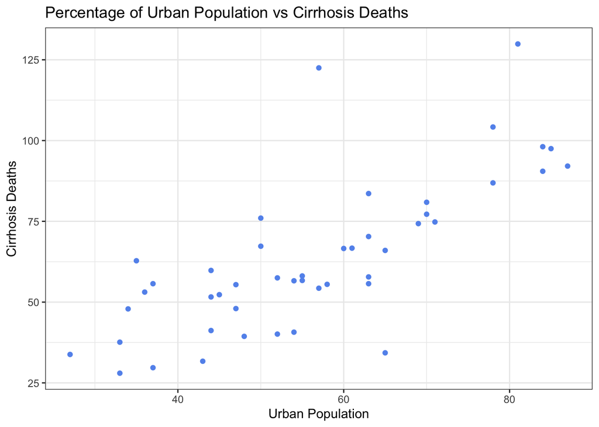

```r
ggplot(data = wine_data) +
  geom_point(aes(x= urban_pop, y=cirrhosis_death), color = "cornflowerblue")+
  labs(title = "Percentage of Urban Population vs Cirrhosis Deaths", x = "Urban Population", y= "Cirrhosis Deaths")+
  theme_bw()
```

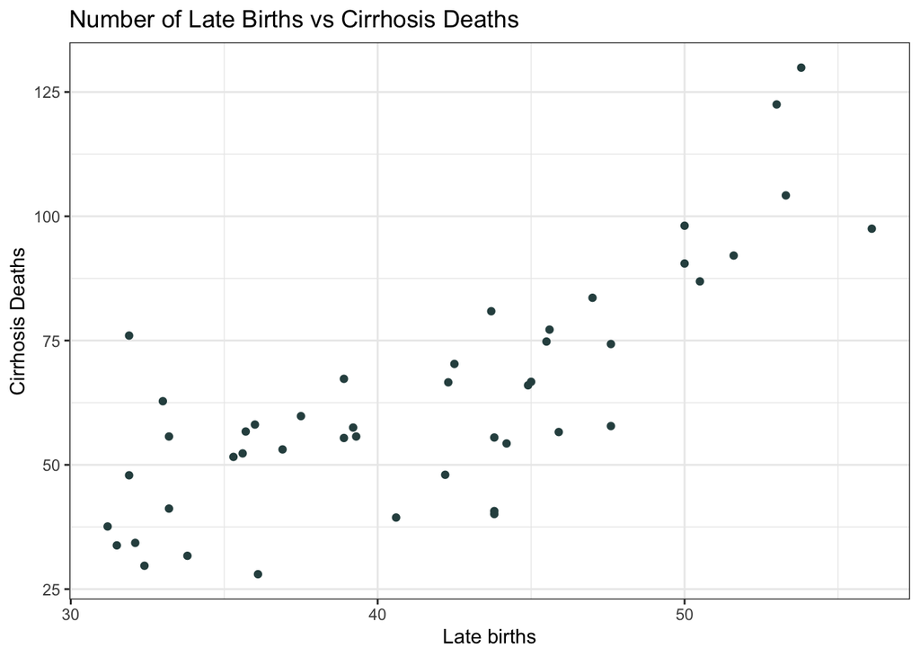

```r
ggplot(data = wine_data) +
  geom_point(aes(x= late_births, y=cirrhosis_death), color = "darkslategray")+
  labs(title = "Number of Late Births vs Cirrhosis Deaths", x = "Late births", y= "Cirrhosis Deaths")+
  theme_bw()
```

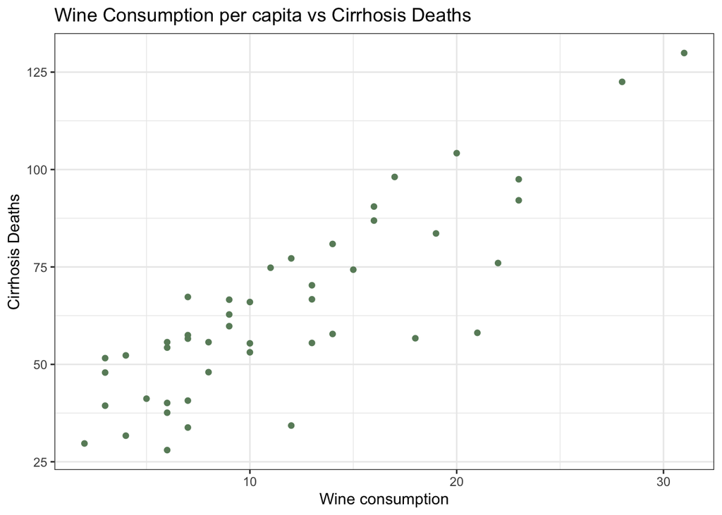

```r
ggplot(data = wine_data) +
  geom_point(aes(x= wine_consumption, y=cirrhosis_death), color = "darkseagreen4")+
  labs(title = "Wine Consumption per capita vs Cirrhosis Deaths", x = "Wine consumption", y= "Cirrhosis Deaths")+
  theme_bw()
```

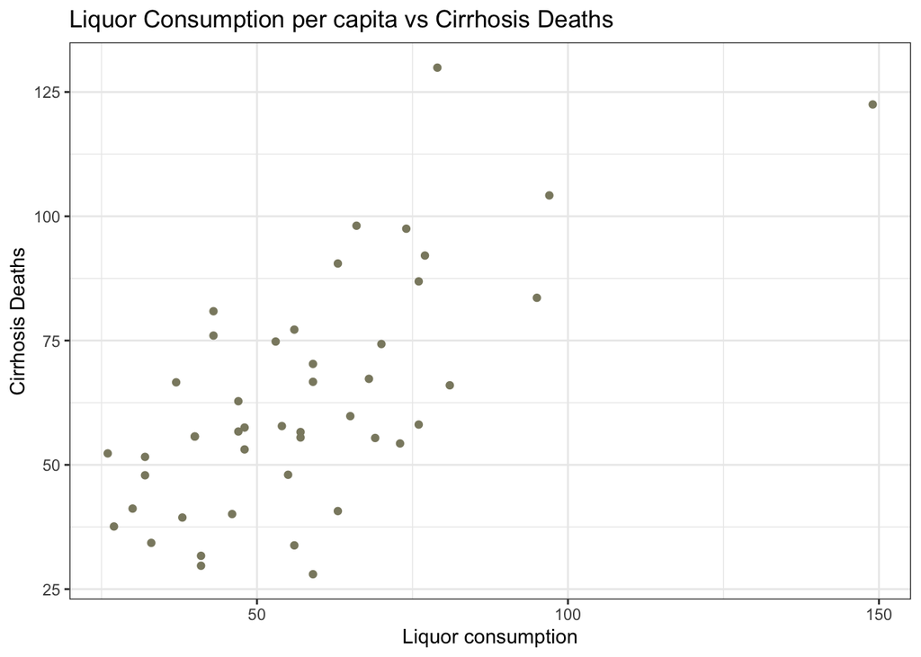

```r
ggplot(data = wine_data) +
  geom_point(aes(x= liquor_consumption, y=cirrhosis_death), color = "lemonchiffon4")+
  labs(title = "Liquor Consumption per capita vs Cirrhosis Deaths", x = "Liquor consumption", y= "Cirrhosis Deaths")+
  theme_bw()
```

Wine and liquor consumption have a linear relationship with cirrhosis deaths

### c)

Fit a series of simple regressions with `cirrhosis_death` as an outcome and each continuous variable as a sole predictor.

```r
fit_regression <- function(df, predictor){
  s <- str_c("cirrhosis_death ~ ", predictor)
  s_form <- as.formula(s)
  mod <- lm(s_form, data = df)
  return(mod)
}

wine_data %>%
  fit_regression("urban_pop") %>%
  tbl_regression()
```

| **Characteristic** | **Beta** | **95% CI**<sup>1</sup> | **p-value** |
| --- | --- | --- | --- |
| urban_pop | 1.1 | 0.82, 1.4 | <0.001 |

<sup>1</sup> CI = Confidence Interval

```r
wine_data %>%
  fit_regression("late_births") %>%
  tbl_regression()
```

| **Characteristic** | **Beta** | **95% CI**<sup>1</sup> | **p-value** |
| --- | --- | --- | --- |
| late_births | 2.6 | 2.0, 3.2 | <0.001 |

<sup>1</sup> CI = Confidence Interval

```r
wine_data %>%
  fit_regression("wine_consumption") %>%
  tbl_regression()
```

| **Characteristic** | **Beta** | **95% CI**<sup>1</sup> | **p-value** |
| --- | --- | --- | --- |
| wine_consumption | 2.9 | 2.3, 3.4 | <0.001 |

<sup>1</sup> CI = Confidence Interval

```r
wine_data %>%
  fit_regression("liquor_consumption") %>%
  tbl_regression()
```

| **Characteristic** | **Beta** | **95% CI**<sup>1</sup> | **p-value** |
| --- | --- | --- | --- |
| liquor_consumption | 0.72 | 0.49, 0.96 | <0.001 |

<sup>1</sup> CI = Confidence Interval

All continuous variables above were significantly associated with cirrhosis deaths (p <0.001 for all, CI not including 0)

### d)

Fully adjusted linear model

```r
multiple_lm <- lm(cirrhosis_death ~ urban_pop + late_births + wine_consumption + liquor_consumption, data = wine_data) %>%
  tbl_regression(label = list(urban_pop ~ "Urban Population",
                              late_births ~ "Late Births",
                              wine_consumption = "Wine Consumption",
                              liquor_consumption = "Liquor Consumption"),
                 intercept = TRUE)
print(multiple_lm)
```

| **Characteristic** | **Beta** | **95% CI**<sup>1</sup> | **p-value** |
| --- | --- | --- | --- |
| (Intercept) | -14 | -37, 9.1 | 0.2 |
| Urban Population | 0.10 | -0.39, 0.59 | 0.7 |
| Late Births | 1.1 | -0.03, 2.3 | 0.056 |
| Wine Consumption | 1.9 | 1.0, 2.7 | <0.001 |
| Liquor Consumption | 0.05 | -0.22, 0.32 | 0.7 |

<sup>1</sup> CI = Confidence Interval

Wine consumption is significantly associated with Cirrhosis deaths in the fully adjusted model. Our model estimates that for every 1 unit increase in wine consumption per capita, cirrhosis deaths increases by 1.9 units, on average, after adjusting for urban population, late births and liquor consumption.

## Guinea Pig Weights

small data file of the average weight (in pounds) for two strains of guinea pig from a series of years in the early 20th century. This data is stored in `data/gpig_dat.csv` and has a variable for year and a variable for each strain. The value in each cell of the strain variable is the weight for that strain in that year.

### a)

Graph guinea pig weights by year in a line plot (using both line and point geoms).

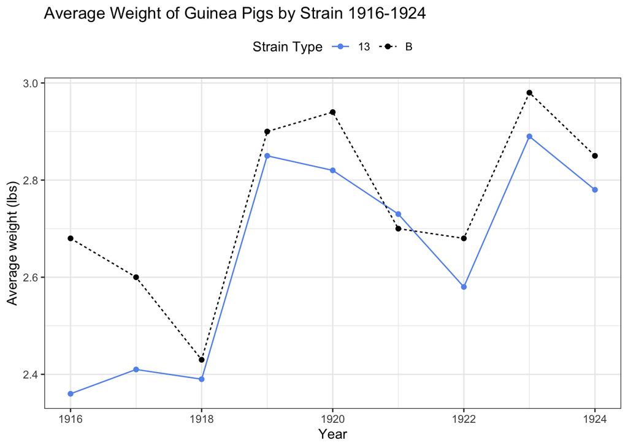

```r
#Read in data
gpig <- read_csv("data/gpig_dat.csv") %>%
  pivot_longer(cols = starts_with("strain"),
               names_to = "strain",
               values_to = "weight",
               names_transform = list(strain = function(x) str_remove(x, "strain ")))

#Plot
ggplot(data = gpig)+
  geom_point(aes(x = year, y = weight, color = strain))+
  geom_line(aes(x = year, y = weight, color = strain, linetype = strain))+
  scale_color_manual(values = c("B" = "black", "13" = "cornflowerblue"))+
  labs(title = "Average Weight of Guinea Pigs by Strain 1916-1924", x = "Year", y = "Average weight (lbs)", color = "Strain Type")+
  theme_bw()+
  theme(legend.position = "top")+
  guides(color = guide_legend(title = "Strain Type"),  linetype = guide_legend(title = "Strain Type"))
```

### b)

Two-sample t-test (equal variances)

```r
weight_res <- t.test(weight ~ strain, data = gpig, var.equal = TRUE)
tstat <- round(weight_res$statistic, 3) #test statistic

df <- weight_res$parameter # degrees of freedom

p <- weight_res$p.value %>% round(4) #p value

weight_summary <- tidy(weight_res)
kable(weight_summary)
```

| estimate | estimate1 | estimate2 | statistic | p.value | parameter | conf.low | conf.high | method | alternative |
| --- | --- | --- | --- | --- | --- | --- | --- | --- | --- |
| -0.1055556 | 2.645556 | 2.751111 | -1.135204 | 0.2730102 | 16 | -0.3026724 | 0.0915613 | Two Sample t-test | two.sided |

There is no significant difference in mean guinea pig weights between the two guinea pig strains at the 5% significance level (test statistic = -1.135, p value = 0.273, df = 16)

### c)

Permutation Test on Minimum Weight

```r
#Calculate test statistic
calculate_ts <- function(df){
  summary <- df %>%
    group_by(strain) %>%
    summarize (min_weight = min(weight))

  b_weight <- summary %>%
    filter(strain == "B") %>%
    pull(min_weight)

  weight_13 <- summary %>%
    filter(strain == "13") %>%
    pull(min_weight)

  difference <- b_weight - weight_13
  return(difference)
}

obs_stat <- calculate_ts (gpig)
obs_stat
```

```
## [1] 0.07
```

```r
#Create function for permutation
permutation_gpig <- function(df){
  permuted <- df %>%
    mutate(strain = sample(strain))
  return(permuted)
}

permuted <- permutation_gpig(gpig)

#Combine functions for permutation and calclculated test statistic
permutation_ts <-function(df){
  permed <- permutation_gpig(df)
  ts <- calculate_ts(permed)
  return(ts)
}
permutation_ts(gpig)
```

```
## [1] 0.03
```

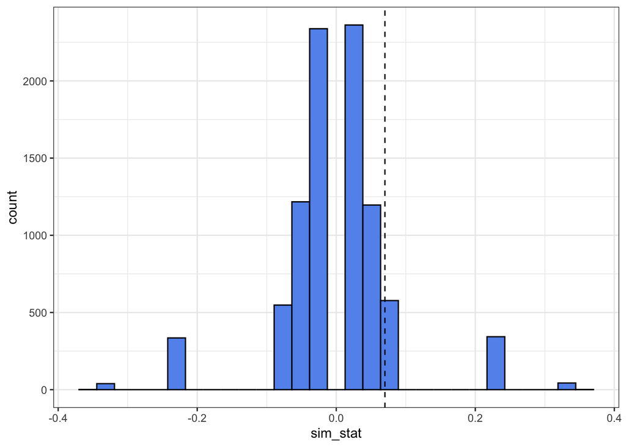

```r
#Repeat at least 2000 times
results <- map_dbl(1:9000, function (x) permutation_ts(gpig))

#Put in tibble for graphing
res_tibble <- tibble(sim_stat = results)

ggplot(data = res_tibble)+
  geom_histogram(aes(x = sim_stat), bins = 30, fill = "cornflowerblue", color = "black")+
  geom_vline(aes(xintercept = obs_stat), linetype = "dashed")+
  theme_bw()
```

```r
#Calculate p value
permute_pval <- res_tibble %>%
  mutate(abs_val_greater = if_else(abs(sim_stat) >= abs(obs_stat), 1,0)) %>%
  group_by(abs_val_greater) %>%
  summarize(n_obs = n()) %>%
  mutate(proportion = n_obs/sum(n_obs)) %>%
  filter(abs_val_greater == 1) %>%
  pull(proportion)

permute_pval
```

```
## [1] 0.2096667
```

We fail to reject the null hypothesis that the difference between the minimum weights are equal between strains at the 5% level of significance. (p value = 0.2096667)

## Question 3

Six datasets with repeated measures of MIRECC GAF Social Functioning scores for an observational study of individuals with schizophrenia. Each dataset includes a GAF SF measurement at a different follow-up visit. These files are stored in the `data/gaf_files` folder.

### a)

Combine all six datasets using a method that will remove any individuals who are not present in ALL datasets.

```r
#Read in datasets
visit1_data <- read_csv("data/gaf_files/visit_1.csv")
visit2_data <- read_csv("data/gaf_files/visit_2.csv")
visit3_data <- read_csv("data/gaf_files/visit_3.csv")
visit4_data <- read_csv("data/gaf_files/visit_4.csv")
visit5_data <- read_csv("data/gaf_files/visit_5.csv")
visit6_data <- read_csv("data/gaf_files/visit_6.csv")

#Join visit 1 and visit 5
joined_15<- inner_join(visit1_data, visit5_data, by = "patient_id")

#Join visit 3 and visit 4
joined_34 <- inner_join(visit3_data, visit4_data, by = "study_id")

#Join visit 2 and visit 6
joined_26 <- inner_join(visit2_data, visit6_data, by = "id")

#Join combined data sets
joined_1534 <- inner_join(joined_15, joined_34, by = c("patient_id" = "study_id"))
join_complete <- inner_join(joined_1534, joined_26, by = c("patient_id" = "id")) %>%
  select(patient_id, site, age, visit_1, visit_2, visit_3, visit_4, visit_5, visit_6)
```

### b)

Facet by site + Mean with 95% CL

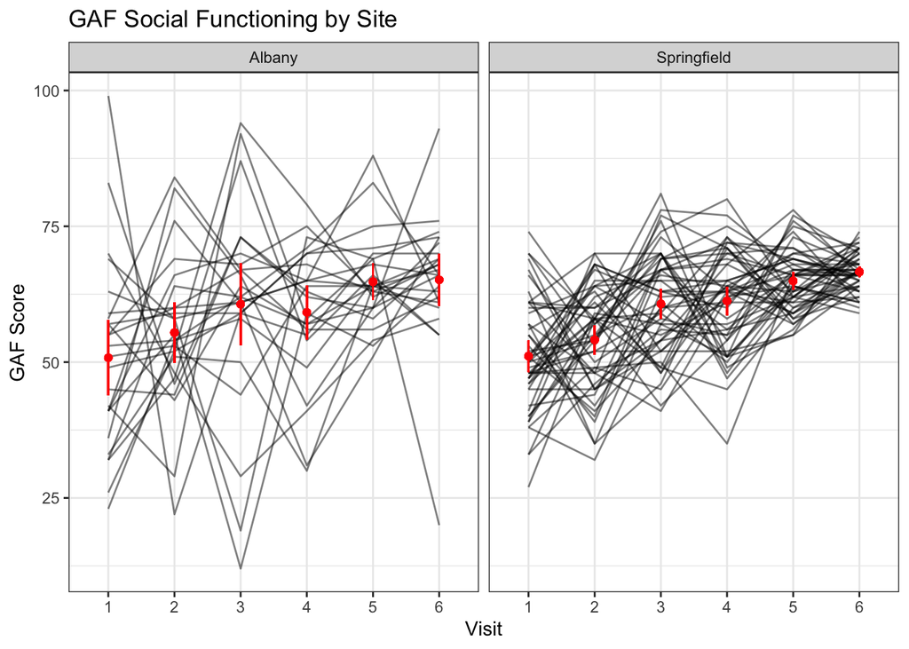

```r
#Convert data from wide to long format
gaf_final <- pivot_longer(data = join_complete,
                         cols = starts_with("visit"),
                         names_to = "visit",
                         values_to = "gaf_score",
                          names_prefix = "visit_")

#Function to calculate CI
calculate_ci <- function(var) {
  if (!is.numeric(var)) {
    return("Input is non-numeric")
  }

  # Compute statistics
  x_bar <- mean(var)
  s <- sd(var)
  n <- length(var)
  z <- 1.96

  # Compute confidence interval bounds
  margin_error <- z * (s / sqrt(n))
  ci_lower <- x_bar - margin_error
  ci_upper <- x_bar + margin_error

  return(c(ci_lower, ci_upper))
}

gaf_plot <- gaf_final %>%
  group_by(site, visit) %>%
   summarise(
    mean_score = mean(gaf_score),
    ci_lower = calculate_ci(gaf_score)[1],
    ci_upper = calculate_ci(gaf_score)[2])


gaf_2final <- gaf_final %>%
  left_join(gaf_plot, by = c("site", "visit"))

#Plot
ggplot(data = gaf_2final ) +
  geom_line(aes(x = visit, y = gaf_score, group = patient_id), color = "black", alpha = 0.5) +
  geom_point(aes(x = visit, y = mean_score), color = "red") +
  geom_segment(aes(x = visit, y = ci_lower, xend = visit, yend = ci_upper), width = 0.5, color = "red") +
  facet_wrap(~site) +
  labs(title = "GAF Social Functioning by Site",
       x = "Visit",
       y = "GAF Score") +
  theme_bw()
```